# Integration of connectivity scores of gene expression data and clustering on other data sources

Pieter Moris

13 april 2016

# Unraveling the connection between chemical structure and gene expression.

**Aim**: Investigate association between *chemical fingerprint* or *biological target* predictions of chemical compounds and the effects they induce in a *gene expression* assay.

**How?** Assess gene expression connectivity scores [@lamb_connectivity_2006; @zhang_simple_2008], but for groupings of compounds not based on their structure.

**Data**: Connectivity Map’s MCF-7 dataset, a breast cancer cell line exposed to several bio-active small molecules.

# Connectivity scores

- Contrast a number of query expression profiles with a set of reference profiles.
- Similarity in terms of which genes are up- or down-regulated.
- Can be positive or negative.

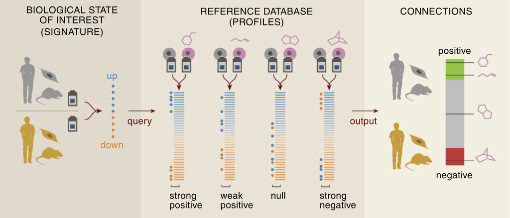

[@lamb_connectivity_2006].

# Agglomerative hierarchical clustering

# Chemical fingerprints and target predictions are binary matrices

```
##                  -2147375257 -2147119955 -2146474760 -2145840573
## metformin                  0           0           0           0
## phenformin                 0           0           0           0
## phenyl biguanide           0           0           0           0
## estradiol                  0           0           0           0
## dexamethasone              0           0           0           0
## verapamil                  0           0           0           0
```

# Tanimoto coefficient is an appropriate measure of similarity

- Often used in cheminformatics [@maccuish_clustering_2011].
- Contrasts two objects *x* and *y* of dimension *k* in terms of the number of common attributes, *c*, versus the number of attributes unique to either object, *a* and *b*.

$$s = \frac{c}{a+b-c}$$

# Agglomerative hierarchical clustering

- Bottom-up approach: repeated merging pairs of similar clusters.
- `agnes` function provided by the `cluster` package.
- Agglomeration method: flexible-Beta with $\alpha = 0.625$ (out-performed average link).
- Prune tree using Gap statistic [@hastie_elements_2009-1].

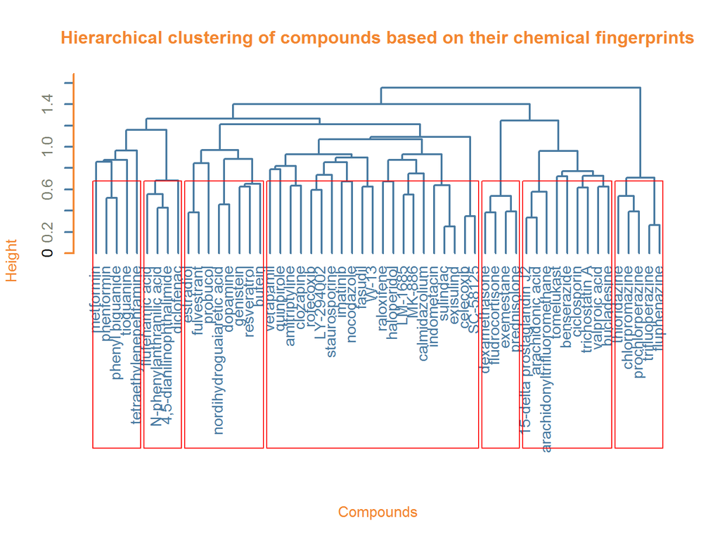

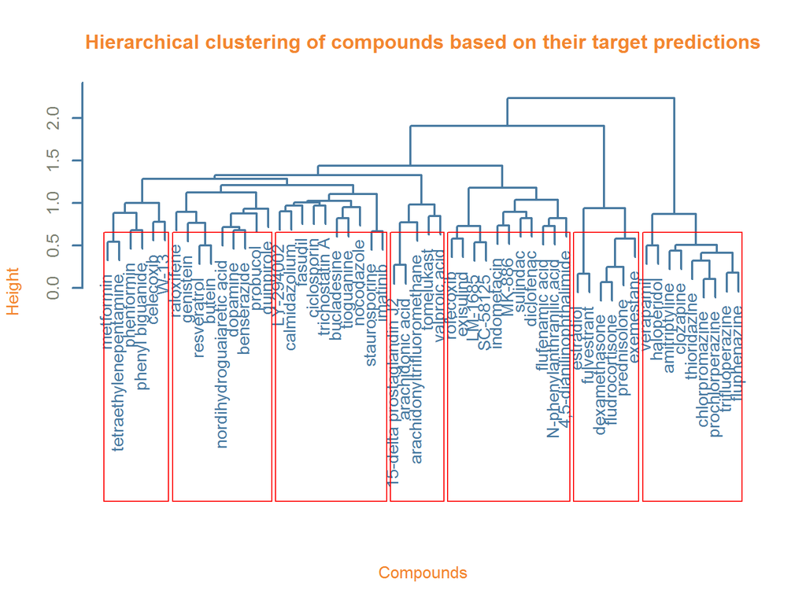

# Connectivity scores using multiple factor analysis

# Multiple factor analysis (Abdi et al., 2013)

- Normalize both the reference and query dataset by dividing each by their first singular value.
- PCA is performed on the combined datasets.
- Factor loadings of compounds represent importance or **connectivity score**.
- **Connectivity sets** represent a local structure or connectivity pattern.
- **Factor scores** of the genes reveal which genes are driving this connectivity.

We are hoping to find high contributions of the **reference compounds** (to a certain component) and also a high loading of the **query compound** on this factor, which would indicate **similarity in gene expression**.

# Within-cluster connectivity

# Within-cluster connectivity

- How well connected are the fingerprint and target clusters based on gene expression?
- **Leave-one-out procedure**: query set contains the full cluster, reference set contains all but one compound.

# Demonstration for cluster 7 based on fingerprints, left-out compound thioridazine

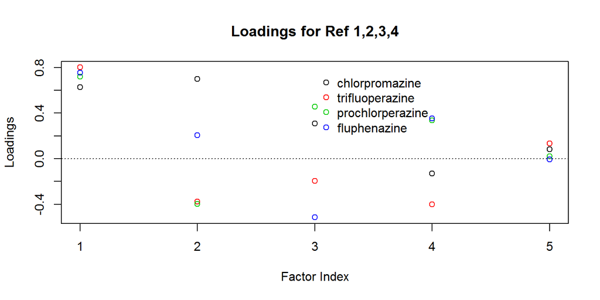

# Average within-cluster connectivity calculation

We use the average of the absolute values of the loadings for the left-out query compound as a measure of the cluster’s **uniformity in terms of its gene expression**.

# Average within-cluster connectivity based on chemical fingerprint clustering

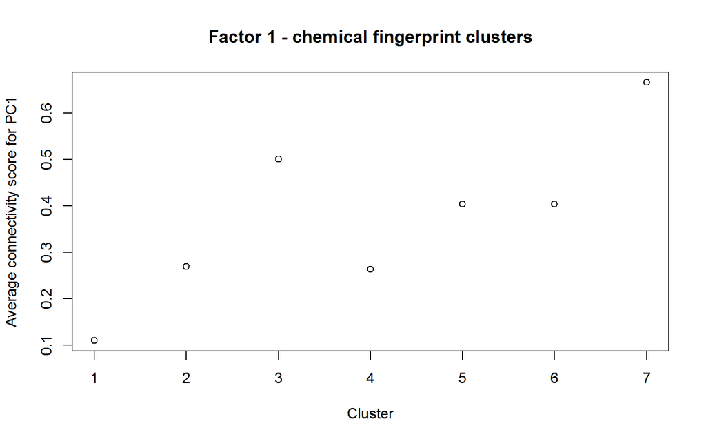

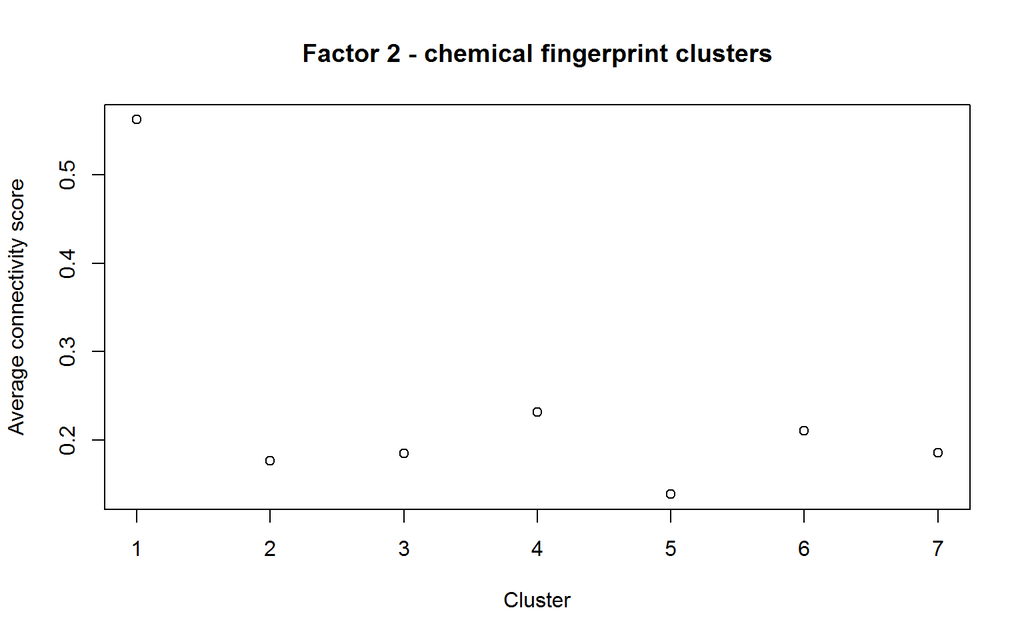

# Cluster 7 shows high within-connectivity for the first factor

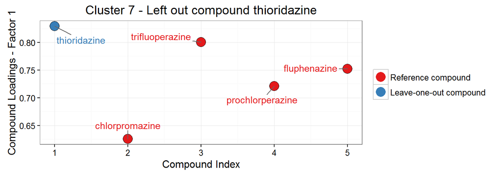

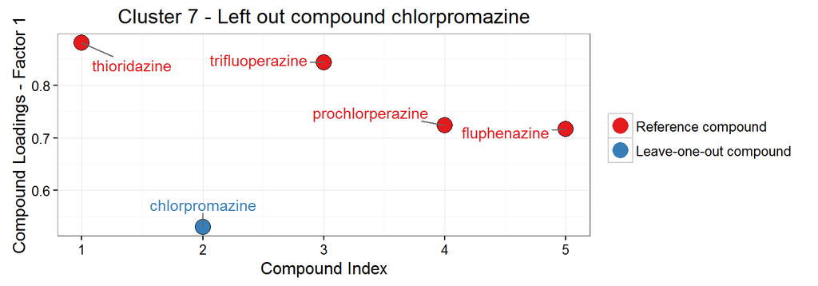

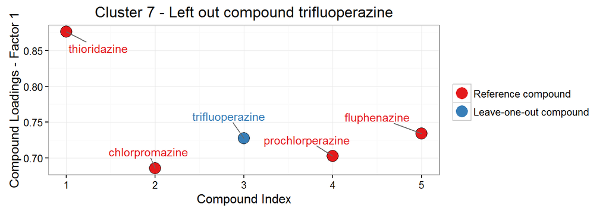

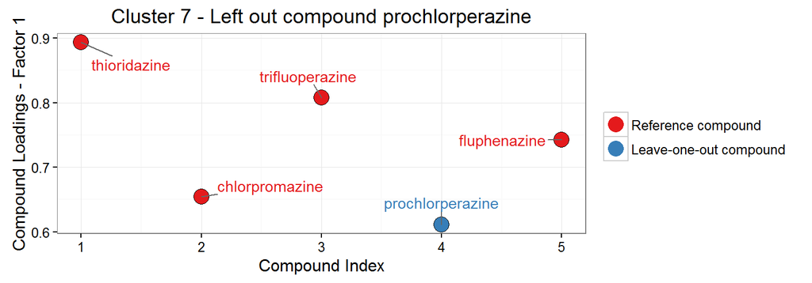

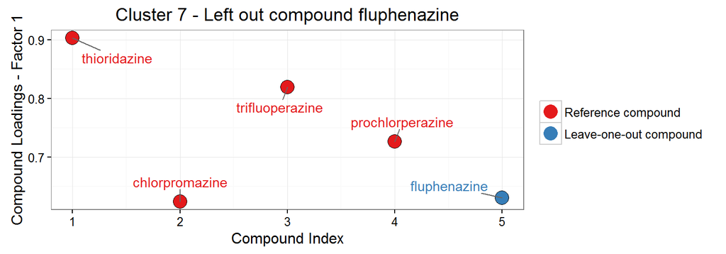

# Average within-cluster connectivity based on target prediction clustering

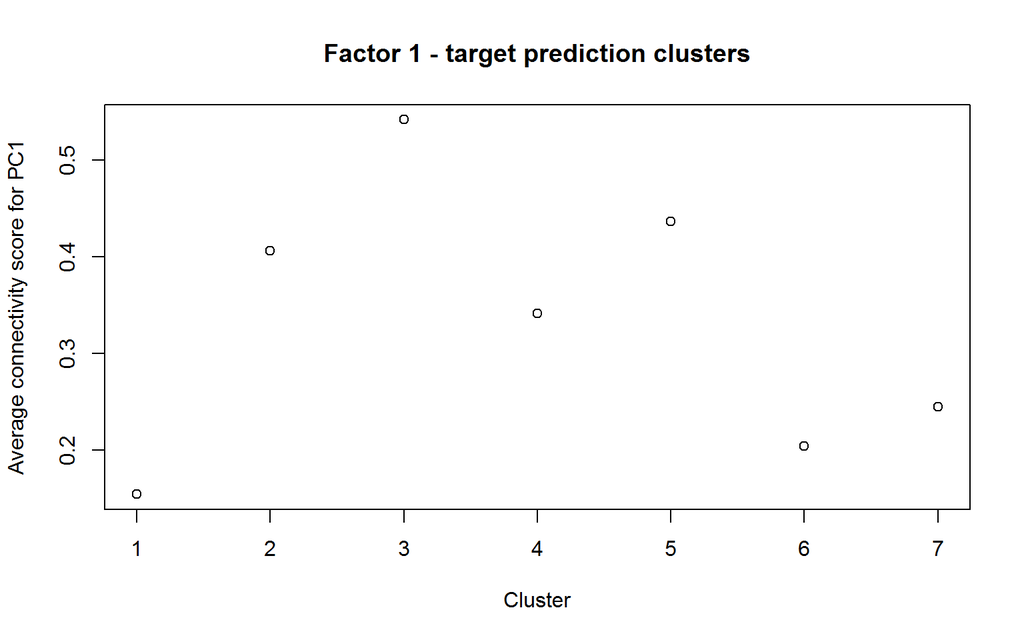

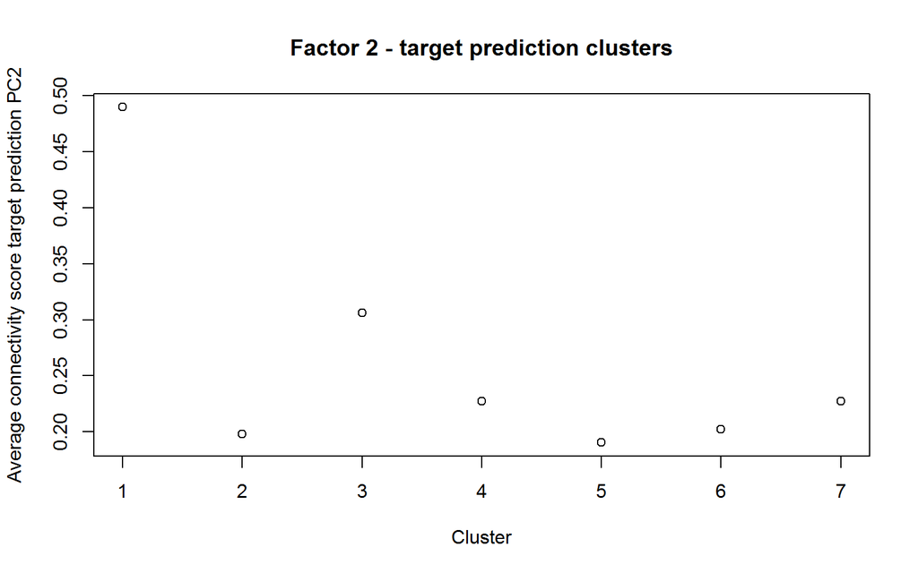

# Cluster 3 contains a known group of antipsychotic drugs

verapamil, amitriptyline, clozapine, thioridazine, haloperidol, chlorpromazine, trifluoperazine, prochlorperazine, fluphenazine

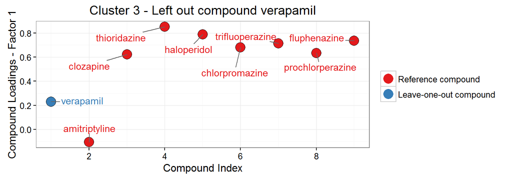

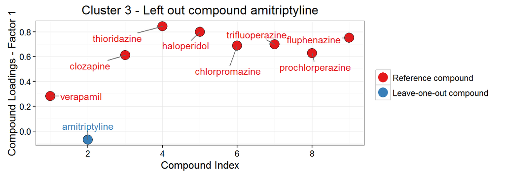

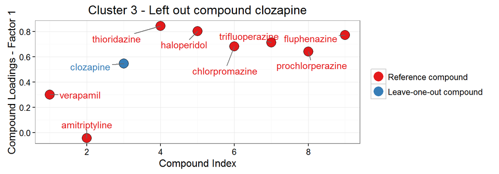

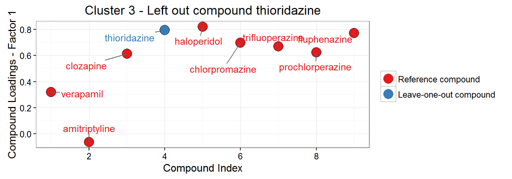

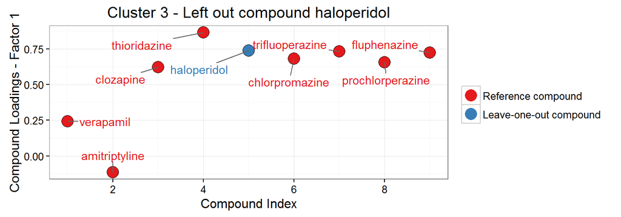

# Between-cluster connectivity

# Between-cluster connectivity

- One cluster as a reference set
- All the other clusters as the query set

Are there **clusters** of different compounds with **similar effects on gene expression**?

# Average between-cluster connectivity

- Average the query loadings per cluster (rows), once for each reference cluster (columns).
- It is most informative to use uniform clusters as a reference:
- i.e. clusters which showed high within-cluster connectivity.

# Chemical fingerprints - first component

| NA | 0.3275 | 0.3212 | 0.3463 | 0.3677 | 0.3115 | 0.2484 |
| --- | --- | --- | --- | --- | --- | --- |
| 0.2627 | NA | 0.2695 | 0.2842 | 0.2492 | 0.2758 | 0.2542 |
| 0.4675 | 0.4614 | NA | 0.5022 | 0.4621 | 0.508 | 0.3271 |
| 0.2785 | 0.2651 | 0.269 | NA | 0.271 | 0.2612 | 0.2644 |
| 0.3661 | 0.3305 | 0.3411 | 0.3525 | NA | 0.3267 | 0.2369 |
| 0.3701 | 0.3945 | 0.3975 | 0.3882 | 0.3656 | NA | 0.2718 |
| 0.2732 | 0.2723 | 0.2474 | 0.3644 | 0.2576 | 0.2735 | NA |

Recall that cluster 7, and to a lesser extent cluster 3, had relatively high within-cluster connectivity for the first factor, and cluster 1 for the second factor.

# Chemical fingerprints - second component

| NA | 0.1438 | 0.1752 | 0.1729 | 0.1438 | 0.1039 | 0.2707 |
| --- | --- | --- | --- | --- | --- | --- |
| 0.1526 | NA | 0.2879 | 0.2862 | 0.2968 | 0.1967 | 0.2233 |
| 0.1322 | 0.1494 | NA | 0.1913 | 0.1282 | 0.3007 | 0.4047 |
| 0.1292 | 0.2107 | 0.2207 | NA | 0.2231 | 0.1571 | 0.2425 |
| 0.1177 | 0.2215 | 0.184 | 0.2115 | NA | 0.1398 | 0.3097 |
| 0.1051 | 0.1148 | 0.1962 | 0.09846 | 0.1283 | NA | 0.2967 |
| 0.1335 | 0.4149 | 0.2563 | 0.4996 | 0.5005 | 0.0886 | NA |

Recall that cluster 7, and to a lesser extent cluster 3, had relatively high within-cluster connectivity for the first factor, and cluster 1 for the second factor.

# Target predictions - first component

| NA | 0.3008 | 0.2935 | 0.323 | 0.3452 | 0.3184 | 0.3207 |
| --- | --- | --- | --- | --- | --- | --- |
| 0.3806 | NA | 0.3616 | 0.4227 | 0.3235 | 0.3785 | 0.3984 |
| 0.3289 | 0.3168 | NA | 0.3553 | 0.2658 | 0.3201 | 0.3656 |
| 0.3392 | 0.3453 | 0.3183 | NA | 0.3054 | 0.3404 | 0.3255 |
| 0.3497 | 0.2917 | 0.2402 | 0.2914 | NA | 0.3232 | 0.3049 |
| 0.2529 | 0.2452 | 0.2631 | 0.2598 | 0.2562 | NA | 0.2468 |
| 0.2733 | 0.2763 | 0.2841 | 0.2801 | 0.256 | 0.2549 | NA |

Recall that cluster 3 had relatively high within-cluster connectivity for the first factor, and cluster 1 for the second factor.

# Target predictions - second component

| NA | 0.1919 | 0.1908 | 0.1916 | 0.1512 | 0.1374 | 0.1467 |
| --- | --- | --- | --- | --- | --- | --- |
| 0.1292 | NA | 0.2531 | 0.2227 | 0.1929 | 0.1957 | 0.1582 |
| 0.1023 | 0.2013 | NA | 0.2936 | 0.3574 | 0.2437 | 0.3318 |
| 0.1295 | 0.2399 | 0.2191 | NA | 0.2111 | 0.1894 | 0.149 |
| 0.1153 | 0.2302 | 0.278 | 0.2536 | NA | 0.2244 | 0.2515 |
| 0.1556 | 0.2148 | 0.2314 | 0.2491 | 0.2508 | NA | 0.2726 |
| 0.1238 | 0.1818 | 0.2029 | 0.1978 | 0.2298 | 0.2421 | NA |

# Visualisation of the between-cluster connectivity

# Visualisation of the between-cluster connectivity

Consider the third target-based cluster consisting of known antipsychotic drugs.

How well **connected** is this cluster to the other clusters?

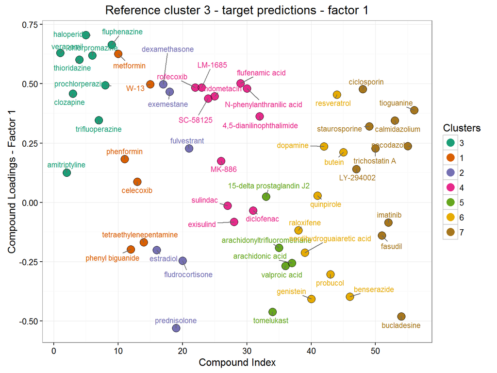

Any of the query compounds or clusters that have high loadings represent a connectivity set: a local structure in the gene expression data of the reference set.

# Which genes are driving this connectivity?

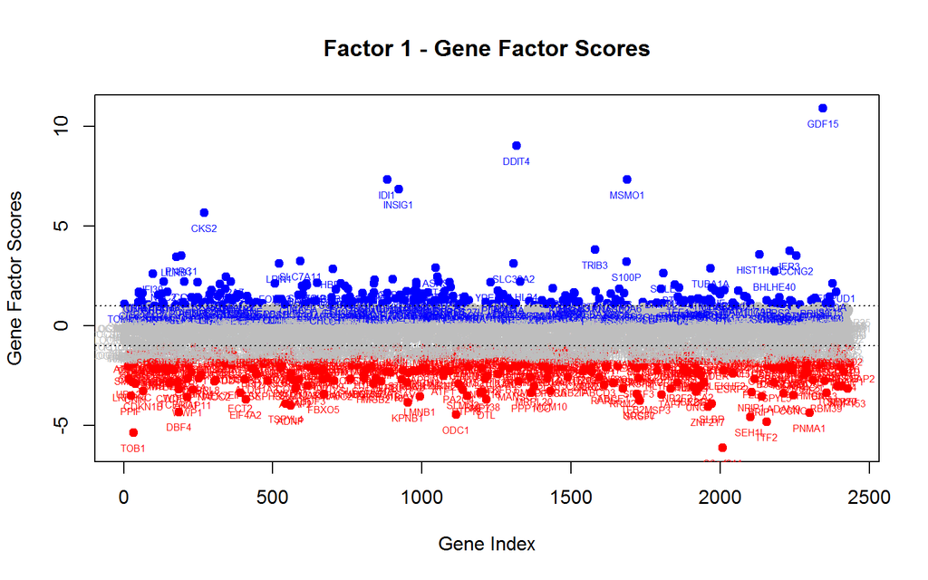

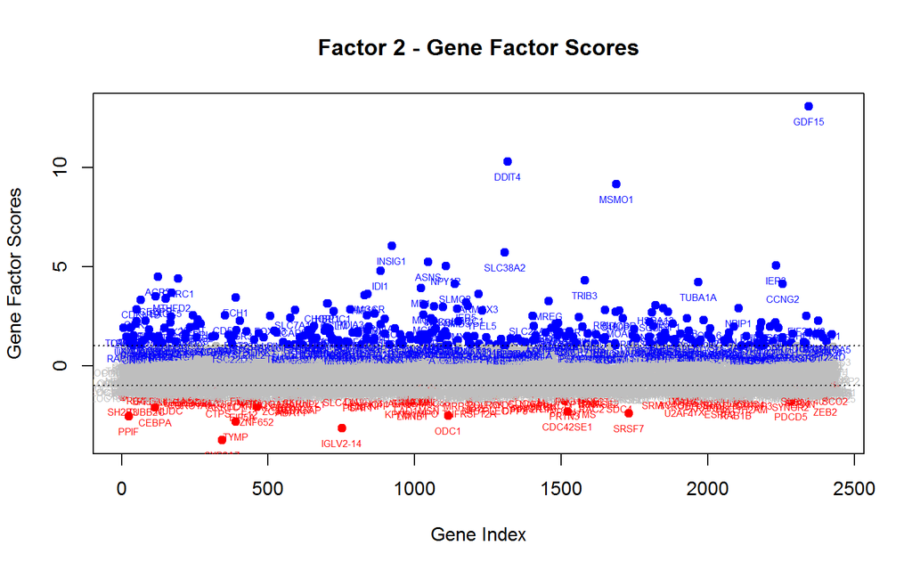

The same genes also drive connectivity structure of second component.

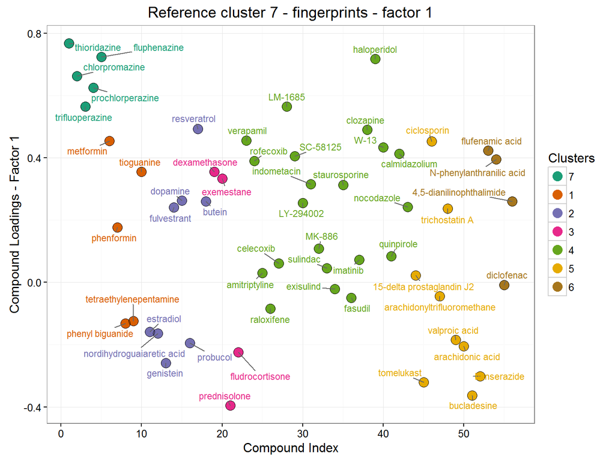

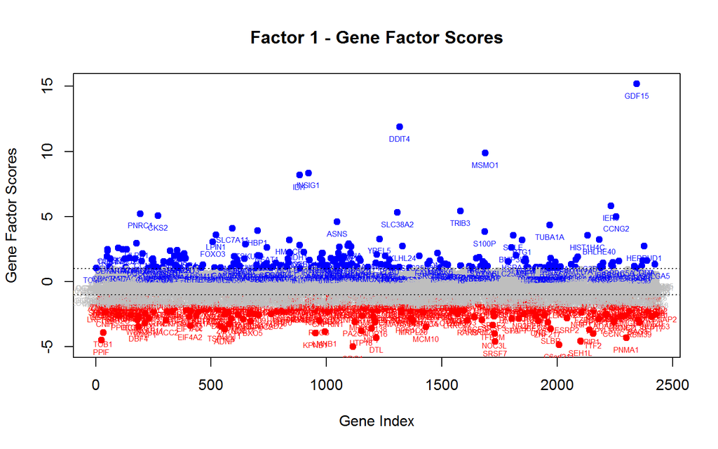

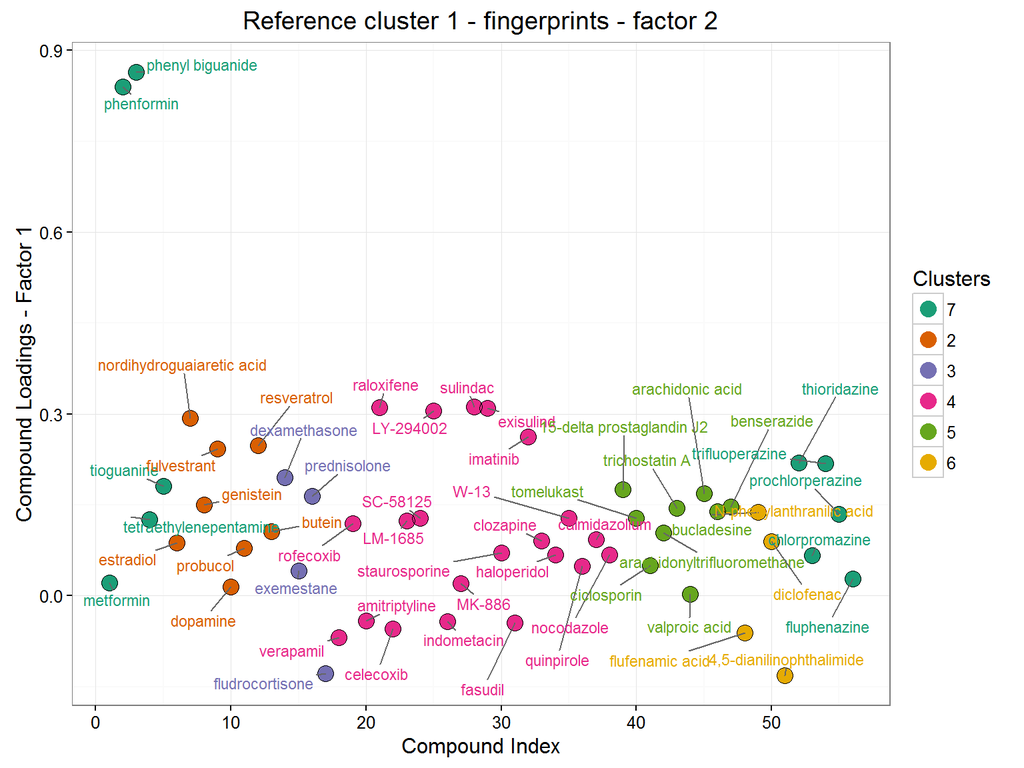

# Concluding remarks

# A better cluster method might improve the results

Some of the clusters would have shown a much higher within-connectivity, if not for a few outlying compounds.

# It is not trivial to choose a factor.

Should factors even be chosen? Or could a combined view be more useful?

# References

- Abdi, Hervé, Lynne J. Williams, and Domininique Valentin. 2013. “Multiple Factor Analysis: Principal Component Analysis for Multitable and Multiblock Data Sets.” Wiley Interdisciplinary Reviews: Computational Statistics 5 (2): 149-79. doi:10.1002/wics.1246.
- Hastie, Trevor, Robert Tibshirani, and J. H. Friedman. 2009. The Elements of Statistical Learning: Data Mining, Inference, and Prediction. 2nd ed. Springer Series in Statistics. New York, NY: Springer.
- Lamb, J. 2006. “The Connectivity Map: Using Gene-Expression Signatures to Connect Small Molecules, Genes, and Disease.” Science 313 (5795): 1929-35. doi:10.1126/science.1132939.
- MacCuish, John D., and Norah E. MacCuish. 2011. Clustering in Bioinformatics and Drug Discovery. Chapman & Hall/CRC Mathematical and Computational Biology Series. Boca Raton, FL: CRC Press.
- Zhang, Shu-Dong, and Timothy W Gant. 2008. “A Simple and Robust Method for Connecting Small-Molecule Drugs Using Gene-Expression Signatures.” BMC Bioinformatics 9 (1): 258. doi:10.1186/1471-2105-9-258.